# CITS4009-project1

Wiz ZHANG(SID:23210735)

## Part1

Introduction The data set analyzed can be obtained from Kaggle platform. It comes from the “Global YouTube Statistics 2023”. https://www.kaggle.com/datasets/nelgiriyewithana/global-youtube-statistics-2023

A collection of YouTube giants, this dataset offers a perfect avenue to analyze and gain valuable insights from the luminaries of the platform. With comprehensive details on top creators’ subscriber counts, video views, upload frequency, country of origin, earnings, and more, this treasure trove of information is a must-explore for aspiring content creators, data enthusiasts, and anyone intrigued by the ever-evolving online content landscape. Immerse yourself in the world of YouTube success and unlock a wealth of knowledge with this extraordinary dataset.[1]

## Part2 Data loading, overview and set up

### 2.1 Load required R packages

ggplot2, dplyr, tidyr and other data visualization and data organization packages

```r
library(ggplot2)
library(gridExtra)
library(dplyr)
library(ggthemes)
library(numform)
library(treemapify)
library(timeDate)
library(lubridate)
library(reshape2)
library(ca)
library(skimr)
library(janitor)
library(flextable)
library(shiny)
library(leaflet)
library(maps)
library(wordcloud)
library(RColorBrewer)
library(scales)
```

### 2.2 Set theme

Set theme for following charts, makes them look same style.

```r
Project_theme <- theme(
  panel.background = element_rect(fill = "#FFFBDC"),  # Light yellow background
  panel.grid.major = element_line(color = "#FFE4A1"), # Light orange major grid lines
  panel.grid.minor = element_blank(), # Remove minor grid lines
  plot.title = element_text(size = 18, hjust = 0.5, color = "darkblue"),  # Title color and size
  axis.title = element_text(size = 16, color = "darkblue"),  # Axis title color and size
  axis.text = element_text(size = 14, color = "black"),   # Axis text color and size
  legend.title = element_text(size = 16, color = "darkblue"), # Legend title color and size
  legend.text = element_text(size = 14, color = "black"),   # Legend text color and size
  legend.background = element_rect(fill = "#FFFBDC"),  # Legend background color
  plot.background = element_rect(fill = "#FFFBDC")   # Background color of the entire plot
)
```

### 2.3 Load the main data

```r
Data_path <- '/Users/weisizhang/Desktop/Global YouTube Statistics.csv'
Youtube <- read.csv(Data_path)
```

### 2.4 Use str command to analyze the data

```r
str(Youtube)
```

The “Global YouTube Statistics” dataset contains 995 observations and 28 variables. The variables can be summarized as follows: Numeric Variables: subscribers: Number of subscribers to the YouTube channel. video_views: Total number of video views. video_views_rank: Ranking based on video views. video_views_for_the_last_30_days: Total video views in the last 30 days. lowest_monthly_earnings: Lowest monthly earnings in USD. highest_monthly_earnings: Highest monthly earnings in USD. lowest_yearly_earnings: Lowest yearly earnings in USD. highest_yearly_earnings: Highest yearly earnings in USD. subscribers_for_last_30_days: Subscribers gained in the last 30 days. created_year: Year when the YouTube channel was created. created_month: Month when the YouTube channel was created. created_date: Date when the YouTube channel was created. Gross.tertiary.education.enrollment.rate: Gross tertiary education enrollment rate. Population: Population of the country. Unemployment.rate: Unemployment rate in the country. Urban_population: Urban population of the country. Latitude: Latitude coordinate of the country. Longitude: Longitude coordinate of the country.

Integer Variables: rank: Rank of the YouTube channel. uploads: Number of video uploads. country_rank: Ranking based on country. channel_type_rank: Ranking based on channel type.

Character Variables: Youtuber: Name of the YouTube channel. category: Category of the YouTube channel. Title: Title of the YouTube channel.. Country: Country of the YouTube channel.. Abbreviation: Abbreviation of the country.. channel_type: Type of the YouTube channel..

### 2.5 Use summary command to analyze data.

I use skimr here, which is similar to summary command but it shows more descriptive statistics for numeric variables than summary command.

```r
skimr::skim(Youtube) %>%
  flextable::flextable()
```

Calculate Right skewness numbers and left skewness numbers

```r
calculate_skewness_percentage <- function(dataframe) {
  #initialize function variables
  right_skewed_count <- 0
  left_skewed_count <- 0
  column_names <- names(dataframe)
  #count the numbers with loops
  for (column in column_names) {
    if (is.numeric(dataframe[[column]])) {
      median_value <- median(dataframe[[column]], na.rm = TRUE)
      mean_value <- mean(dataframe[[column]], na.rm = TRUE)
      if (mean_value > median_value) {
        right_skewed_count <- right_skewed_count +1
      } else if (mean_value < median_value) {
        left_skewed_count <- left_skewed_count +1
      }
    }
  }
  #calculate percentage with the count result
  right_percentage <- round((right_skewed_count / ncol(dataframe)) * 100, 2)
  left_percentage <- round((left_skewed_count / ncol(dataframe)) * 100, 2)

  return(list(right_percentage, left_percentage))
}

# Use function to get the calculation result
results <- calculate_skewness_percentage(Youtube)
cat("\n")
```

```r
cat("Percentage of right-skewed columns is:", results[[1]], "%\n")
```

```
## Percentage of right-skewed columns is: 50 %
```

```r
cat("Percentage of left-skewed columns is:", results[[2]], "%\n")
```

```
## Percentage of left-skewed columns is: 21.43 %
```

Based on the result of Skewness test, The percentage of rigt-skewed columns is 50%, and the percentage of left-skewed columns is only 21.43%, so columns data is character so we can’t make the skewness test. Therefore, most of the data is right skewed. Such as subscribers; uploads; lowest_monthly_earnings.

### 2.6 Use head command to analyze data.

```r
head(Youtube,n=100)
```

## Part3 Initial data cleanning and transformations

We need to proceed initial data cleaning and transformations before our analysis.

### 3.1 Check column names and make adjustments.

3.1.1 Use names function check names first , then make the decision.

```r
names(Youtube)
```

3.1.2 Use janitor package and rename function adjust column names to ensure uniform formatting.

janitor::clean_names() is a very popular function in the package whose main purpose is to convert the column names of dataframes into a clean, uniform format. Here is the main logic and rules of this function: 1.All characters to lowercase 2.Spaces are converted to underscores 3.Non-alphanumeric characters are removed 4.Numbers before text moved to the end 5.Underline after keyword in R

```r
Youtube <- janitor::clean_names(Youtube)

# Print new names to ensure everything good.
print(colnames(Youtube))
```

```
##  [1] "rank"                                "youtuber"
##  [3] "subscribers"                         "video_views"
##  [5] "category"                            "title"
##  [7] "uploads"                             "country"
##  [9] "abbreviation"                        "channel_type"
## [11] "video_views_rank"                    "country_rank"
## [13] "channel_type_rank"                   "video_views_for_the_last_30_days"
## [15] "lowest_monthly_earnings"             "highest_monthly_earnings"
## [17] "lowest_yearly_earnings"              "highest_yearly_earnings"
## [19] "subscribers_for_last_30_days"        "created_year"
## [21] "created_month"                       "created_date"
## [23] "gross_tertiary_education_enrollment" "population"
## [25] "unemployment_rate"                   "urban_population"
## [27] "latitude"                            "longitude"
```

### 3.2Inspect&Adjust data types

Use sapply function to check data types, adjust wrong data typs.

```r
data_types <- sapply(Youtube, class)
print(data_types)

data_sample <- sapply(Youtube,head)
data_sample
```

### 3.3 Handle Missing value

3.3.1 Backup the original data, build up a new variable called “Youtube_cleaned”

```r
Youtube_cleaned <- Youtube
```

3.3.2 identify numeric and character type,change 0 and “nan” to NA. kill the rows with at least 50%(14) of NA in 28 variables.

```r
#Change 0 or 'nan' or 'NaN' to NA value
Youtube[Youtube == 0|Youtube=='nan'|Youtube == "NaN"] <- NA
#Count how many NA values in each row
Youtube$na_count <- rowSums(is.na(Youtube))
# Only keep the rows with NA value number less than 14.
Youtube_cleaned <- Youtube[Youtube$na_count <14,]
```

3.3.3 Calculate how many missing values in each column, handle them.

```r
# Calculate missing value number
count_missing <- function(df) {
  sapply(df, FUN = function(col) sum(is.na(col)) )
}
# Calculate percentage of missing value
percentage_missing <- function(df) {
  sapply(df, FUN = function(col) round(sum(is.na(col)) / length(col) * 100, 2) )
}

nacounts <- count_missing(Youtube_cleaned)
napercents <- percentage_missing(Youtube_cleaned)

# output the result
hasNA = which(nacounts > 0)
data.frame(Column = names(nacounts[hasNA]),
           Missing_Values = nacounts[hasNA],
           Percentage_Missing = napercents[hasNA])
```

```
##                                                                  Column
## video_views                                                 video_views
## category                                                       category
## uploads                                                         uploads
## country                                                         country
## abbreviation                                               abbreviation
## channel_type                                               channel_type
## video_views_rank                                       video_views_rank
## country_rank                                               country_rank
## channel_type_rank                                     channel_type_rank
## video_views_for_the_last_30_days       video_views_for_the_last_30_days
## lowest_monthly_earnings                         lowest_monthly_earnings
## highest_monthly_earnings                       highest_monthly_earnings
## lowest_yearly_earnings                           lowest_yearly_earnings
## highest_yearly_earnings                         highest_yearly_earnings
## subscribers_for_last_30_days               subscribers_for_last_30_days
## created_year                                               created_year
## created_month                                             created_month
## created_date                                               created_date
## gross_tertiary_education_enrollment gross_tertiary_education_enrollment
## population                                                   population
## unemployment_rate                                     unemployment_rate
## urban_population                                       urban_population
## latitude                                                       latitude
## longitude                                                     longitude
##                                     Missing_Values Percentage_Missing
## video_views                                      2               0.21
## category                                        39               4.07
## uploads                                         17               1.77
## country                                         85               8.87
## abbreviation                                    85               8.87
## channel_type                                    14               1.46
## video_views_rank                                 1               0.10
## country_rank                                    80               8.35
## channel_type_rank                               16               1.67
## video_views_for_the_last_30_days                22               2.30
## lowest_monthly_earnings                         81               8.46
## highest_monthly_earnings                        52               5.43
## lowest_yearly_earnings                          52               5.43
## highest_yearly_earnings                         43               4.49
## subscribers_for_last_30_days                   308              32.15
## created_year                                     3               0.31
## created_month                                    3               0.31
## created_date                                     3               0.31
## gross_tertiary_education_enrollment             86               8.98
## population                                      86               8.98
## unemployment_rate                               86               8.98
## urban_population                                86               8.98
## latitude                                        86               8.98
## longitude                                       86               8.98
```

The column which has more than 10% missing value is “subscribers_for_last_30_days”

3.3.4 Use Medium to replace the NA Base on the result of skewness test, most of data is right skewed, so we should use medium which is better than using mean value, because mean value would change the right skewed structure. Here, I change the columns where more than 10% of data is NA.

```r
change_to_median_cols <- c("subscribers_for_last_30_days")
for (col in change_to_median_cols) {
    median_val <- median(Youtube_cleaned[[col]], na.rm = TRUE)
    Youtube_cleaned[[col]][is.na(Youtube_cleaned[[col]])] <- median_val
}
```

3.3.5 Change the NA in character_columns into “Missing”

```r
character_columns <- c("youtuber","category","title","country","abbreviation","channel_type","created_month")

for (col in character_columns) {
  Youtube_cleaned[[col]][is.na(Youtube_cleaned[[col]])] <- "Missing"
}
```

### 3.4 Handle repeating lines

```r
# Use unique function handle repeating lines
Youtube_cleaned_unique <- unique(Youtube_cleaned)
Youtube_cleaned <- unique(Youtube_cleaned)
```

### 3.5 Change the data type from character to factor for ‘category’, ‘country’, ‘channel type’

```r
factor_columns <- c("category", "country", "channel_type")
#Use mutate adjust factor_columns, change then to factor type
Youtube_cleaned <- Youtube_cleaned %>%
  mutate(across(all_of(factor_columns), as.factor))
```

### 3.6 Add missing value indicator for each column if the value is NA mark 1 either mark 0

```r
for (col in names(Youtube_cleaned)) {
  indicator_name <- paste0(col, "_NA_indicator")
  Youtube_cleaned[[indicator_name]] <- as.integer(is.na(Youtube_cleaned[[col]]))
}
```

### 3.7 Add new column which might be used in the future.

3.7.1 Add full time column

```r
# First, ensure that the 'created_date' column is in integer format
Youtube_cleaned$created_date <- as.integer(as.character(Youtube_cleaned$created_date))

# Define a vector of month names
month_names <- c("Jan", "Feb", "Mar", "Apr", "May", "Jun", "Jul", "Aug", "Sep", "Oct", "Nov", "Dec")

# Create a vector of two-digit month numbers using sprintf
month_numbers <- sprintf("%02d", 1:12)

# Create a mapping between month names and month numbers
month_mapping <- setNames(month_numbers, month_names)

# Update the 'full_date' column by combining year, month, and day
Youtube_cleaned$full_date <- as.Date(paste(Youtube_cleaned$created_year,
                                   Youtube_cleaned$created_month %>% match(month_names) %>% month_mapping[.],
                                   sprintf("%02d", Youtube_cleaned$created_date),
                                   sep = "-"),
                             format = "%Y-%m-%d")
```

## Part4 Analysis

### Figure 1

Distribution of YouTube Channel Subscribers

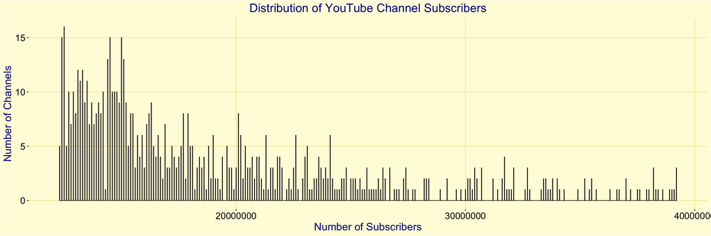

```r
# Make a new variable, do not use original data
subscribers_analysis <- Youtube_cleaned

#Inspect outliers
outliers <- boxplot.stats(subscribers_analysis$subscribers)$out

# Change outliers into NA value
subscribers_analysis$subscribers[subscribers_analysis$subscribers %in% outliers] <- NA
#delete NA
subscribers_analysis <- na.omit(subscribers_analysis)
# Draw histogram
ggplot(subscribers_analysis, aes(x = subscribers)) +
  geom_histogram(binwidth = 5000, color = "black") +
  labs(title = "Distribution of YouTube Channel Subscribers",
       x = "Number of Subscribers",
       y = "Number of Channels") +
  Project_theme +
  #Ensure X axis number is not scientific type
  scale_x_continuous(labels = function(x) format(x, scientific = FALSE))
```

### Figure2 Heatmap of Channel Categories by Country

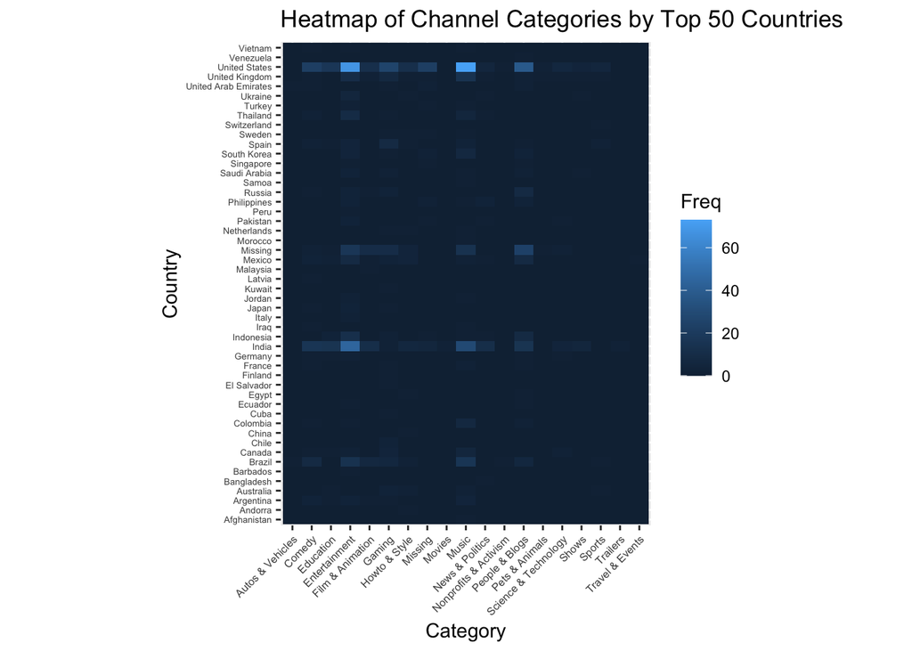

```r
channel_country <- table(Youtube_cleaned$category, Youtube_cleaned$country)
# Convert channel_country to a data frame
channel_df <- as.data.frame(channel_country)
colnames(channel_df) <- c("Category", "Country", "Freq")

# Get the top 50 countries based on total frequency
top_50_countries <- channel_df %>%
  group_by(Country) %>%
  summarize(total_freq = sum(Freq)) %>%
  arrange(desc(total_freq)) %>%
  head(50) %>%
  pull(Country)

# Filter the data to include only the top 50 countries
top_channel_df <- channel_df %>%
  filter(Country %in% top_50_countries)

# Draw the heatmap
ggplot(top_channel_df, aes(Category, Country)) +
  geom_tile(aes(fill = Freq)) +
  labs(title = "Heatmap of Channel Categories by Top 50 Countries") +
  theme(axis.text.x = element_text(angle = 45, hjust = 1, size = 6)) +
  theme(axis.text.y = element_text(size = 5)) +
  coord_fixed(ratio = 0.5)
```

### Figure 3 “Interactive Shiny plots”

Check the outliers of each columns.

```r
#Define the selection set for boxplot
Boxplot_choices <- c("rank", "video_views_rank", "country_rank", "channel_type_rank", "video_views_for_the_last_30_days",
"lowest_monthly_earnings", "highest_monthly_earnings", "lowest_yearly_earnings",
"highest_yearly_earnings", "subscribers_for_last_30_days", "created_year", "created_date",
"gross_tertiary_education_enrollment", "population", "unemployment_rate",
"urban_population", "latitude", "longitude")

# Get the actual country count data
country_counts <- as.data.frame(table(Youtube_cleaned$country))

# Map data
world_map <- map_data("world")
#Set centroids for each country
country_centroids <- world_map %>%
  group_by(region) %>%
  summarise(long = mean(long), lat = mean(lat))

# Merge country_counts with centroids
merged_data <- merge(country_counts, country_centroids, by.x = "Var1", by.y = "region", all.x = TRUE)

#Get Youtube term matrix based on user's choice for Word Cloud Plot
getYoutubeTermMatrix <- function(selection) {
  if(selection == "Country") {
    terms <- table(Youtube_cleaned$country)
  } else if (selection == "Category") {
    terms <- table(Youtube_cleaned$category)
  } else if (selection == "Channel Type") {
    terms <- table(Youtube_cleaned$channel_type)
  }
  print(terms)
  return(terms)
}




# Shiny UI
ui <- fluidPage(
  #The code for vertical layout
  verticalLayout(
    #Using tabsetPannel to create tabs for each plot[Reference 3]
    tabsetPanel(type = "tabs",
                #First, BoxPlot
                tabPanel("Boxplot",
                         titlePanel("Boxplot Visualization"),
                         verticalLayout(
                           wellPanel(
                             #Meun to select a column for boxplot
                             selectInput(
                               "selectedColumn",
                               "Choose a Column for Boxplot",
                               choices = Boxplot_choices ,
                             )
                           ),
                           mainPanel(
                             plotOutput(outputId = "box_plot")
                           )
                         )
                ),
                #Second, Faceted Scatter Plot
                tabPanel("facetedScatter",
                         titlePanel("Faceted Scatter Plot"),
                         verticalLayout(
                           wellPanel(
                             #Menu to choose facet variable
                             selectInput(
                               "facetSelect", "Facet By:",
                               choices = c("Category", "Country")
                             )
                           ),
                           mainPanel(
                             plotOutput(outputId = "facetedScatter",width = "800px",height = "2000px")
                           )
                         )
                ),
                #Third, Map plot
                tabPanel("Geographical Distribution",
                         titlePanel("Geographical Distribution"),
                         verticalLayout(
                           #Sliders to control latitude&longitude
                           sliderInput("latRange", "Latitude Range:", min = -90, max = 90, value = c(-90, 90)),
                           sliderInput("longRange", "Longitude Range:", min = -180, max = 180, value = c(-180, 180))
                         ),
                         mainPanel(
                           plotOutput(outputId = "map_plot",width = "800px",height = "500px")
                         )
                ),
                #Forth, Scarlet Plot
                tabPanel("Category Scarlet Plot",
                         titlePanel("Relationship between Category and Variable"),
                         sidebarLayout(
                           sidebarPanel(
                             #Menu to choose variable
                             selectInput(
                               "numeric_var",
                               "Select Numeric Variable:",
                               choices = c("subscribers", "video views")
                             )
                           ),
                           mainPanel(
                             plotOutput("scarlet_plot", width = "600px", height = "800px")
                           )
                         )
                ),
                #Fifth, Density Plot
                tabPanel("Earning density plot",
                         titlePanel("Density Plot of earning"),
                         sidebarLayout(
                           sidebarPanel(
                             #Menu to select the 4 earning variables
                             selectInput(
                               "earning_period",
                               "Select earning period(log)",
                               choices = c(
                                 "Lowest yearly earning" = "lowest_yearly_earnings",
                                 "Highest yearly earning" = "highest_yearly_earnings",
                                 "Lowest monthly earning" = "lowest_monthly_earnings",
                                 "Highest monthly earning" = "highest_monthly_earnings"
                                 )
                               )
                             ),
                           mainPanel(plotOutput("density_plot"))
                           )
                         ),
                #Sixth, Word Cloud Plot
                tabPanel("Word Cloud",
               titlePanel("World Cloud"),
               sidebarLayout(
                 sidebarPanel(
                   #Menu to select category for word cloud plot
                   selectInput("selection", "Choose a category", choices = c("Channel Type","Country","Category")),
                   #Button to update the word cloud
                   actionButton("update", "Change"),
                   #Horizontal rule for UI separation
                   hr(),
                   #Slider to control words freq
                   sliderInput("freq", "Minimum Frequency:", min = 1, max = 50, value = 1),
                   #Slider to control words num
                   sliderInput("max", "Maximum Number of Words:", min = 1, max = 300, value = 300)
                 ),
                 mainPanel(plotOutput("wordcloud_plot"))
               )
      )
                )
    )
  )



# Shiny server
server <- function(input, output) {

  # Define the function for killing outliers before drawing plots
  remove_outliers <- function(data, column_name) {
    #Identify outliers for specified column
    outliers <- boxplot.stats(data[[column_name]])$out
    #Replace outliers with NA
    data[[column_name]][data[[column_name]] %in% outliers] <- NA
    return(data)
  }

  #Code for Box Plot
  output$box_plot <- renderPlot({
    #Remove outliers first
    Youtube_no_outliers <- remove_outliers(Youtube_cleaned, input$selectedColumn)
    #Create a boxplot for chosen column
    p <- ggplot(Youtube_no_outliers, aes_string(y = input$selectedColumn)) +
      geom_boxplot() +
      labs(title = paste("Boxplot of", input$selectedColumn)) +
      Project_theme
    print(p)
  })

  # Code for Faceted Scatter Plot
  output$facetedScatter <- renderPlot({
    #Set facet variable base on user input
    if (input$facetSelect == "Category") {
      facet_var <- "category"
    } else if (input$facetSelect == "Country") {
      facet_var <- "country"
    }
    #Create scatter plot with faceting
    p <- ggplot(Youtube_cleaned, aes(x = subscribers, y = video_views)) +
      geom_point(alpha = 0.5) +
      facet_wrap(as.formula(paste("~", facet_var)), ncol = 2) +
      labs(title = "Faceted Scatter plot of Subscribers vs Video Views") +
      Project_theme +
      #Log transform for better visualzation , this is better than scientific notation I use GPT for helping me learn here.
      scale_x_continuous(trans = "log10", breaks = trans_breaks("log10", function(x) 10^x), labels = trans_format("log10", math_format(10^.x)))
    print(p)
  })


  #Code for Map Plot
  output$map_plot <- renderPlot({
    #Filter the data based on selected latitude&longtitude ranges
    filtered_data <- merged_data %>%
      filter(lat >= input$latRange[1] & lat <= input$latRange[2] & long >= input$longRange[1] & long <= input$longRange[2])
    #Create the map plot with points which shows YouTubers' locations
    ggplot() +
      geom_polygon(data = world_map, aes(x = long, y = lat, group = group), fill = "white", color = "grey") +
      geom_point(data = filtered_data, aes(x = long, y = lat, size = Freq), color = "blue") +
      Project_theme +
      scale_size_continuous(name = "Number of YouTubers", range = c(1, 5))
  })


  #Code for Scarlet Plot
  output$scarlet_plot <- renderPlot({
    #X axis should be the choosed variable
    x_var <- switch(input$numeric_var,
                    "subscribers" = "subscribers",
                    "video views" = "video_views")
    #Create scarlet plot here
    ggplot(Youtube_cleaned, aes_string(x = x_var, y = "category", color = "category")) +
      geom_point() +
      ggtitle(paste("Relationship between", input$numeric_var, "and Category")) +
      ylab("Channel Type") +
      xlab(input$numeric_var) +
      Project_theme +
      #Log transform for better visualzation , this is better than scientific notation I use GPT for helping me learn here.[Reference 4]
      scale_x_continuous(trans = "log10", breaks = trans_breaks("log10", function(x) 10^x), labels = trans_format("log10", math_format(10^.x)))

  })


  #Code for Density Plot
  output$density_plot <- renderPlot({
    #Remove outliers first
    Youtube_no_outliers <- remove_outliers(Youtube_cleaned, input$earning_period)
    #Log transform for better visualzation , this is better than scientific notation
    selected_data <- log(Youtube_no_outliers[[input$earning_period]])
    ggplot(Youtube_no_outliers, aes(x=selected_data))+
      geom_density(fill = "blue", alpha=0.5) +
      labs(title = paste("Density Plot of", input$earning_period),
           x = "Earnings (log-scale)",
           y = "Density")
  })

  #Generating the Word Cloud[Reference 2]
  terms <- reactive({
    input$update
    isolate({
      withProgress({
        setProgress(message = "Processing corpus...")
        getYoutubeTermMatrix(input$selection)
      })
    })
  })

  wordcloud_rep <- repeatable(wordcloud)


  output$wordcloud_plot <- renderPlot({
    v <- terms()
    wordcloud_rep(names(v), as.numeric(v), scale = c(10,1),
                  min.freq = input$freq, max.words = input$max,
                  colors = brewer.pal(8, "Dark2"))
  })
}
shinyApp(ui, server)
```

Shiny applications not supported in static R Markdown documents

### 1.Boxplot

Most of the variables have really high outliers but some of the outliers is fine as the data is from the top 995 YouTubers, sometimes it is reasonable that some top YouTuber may have extremely higher video views; earnings than average level.

### 2.facetedScatter

For the faceted scatter plot of subscribers and video views, most of them don’t show a correlation, only Entertainment, Gaming, Film&Animation, and Music show a clear linear correlation, which, based on the heat map above, may be due to the fact that these categories have the most subscriptions, and the data just happens to be the top 995 YouTubers leading to this. For the Country and Video Views graphs, again not much correlation is shown, except for India, Brazil and the US, which show a linear correlation, due to the fact that these countries have the most subscribers.

### 4.Category Scarlet Plot

For Subscribers vs. channel type, Music and Entertainment channels have the most subscribers, and Gaming and People & Blogs channels have fewer subscribers. For Number of video views vs. channel type, Entertainment and music channels have the highest number of views, while Howto & Style channels have a wide distribution of views.

### 5.Earning density plot

Most channels earn less than 100k dollar. A small number of channels earn over 1 million dollar. We can find that the median income of most YouTubers for all 4 variables is unusually high and satisfies a normal distribution，highly right skewed.

### Reference

1. Nidula Elgiriyewithana. (2023 Aug). Global YouTube Statistics 2023 https://www.kaggle.com/datasets/nelgiriyewithana/global-youtube-statistics-2023
2. https://shiny.posit.co/r/gallery/start-simple/word-cloud/
3. https://github.com/rstudio/shiny-examples/tree/main/006-tabsets
4. GPT3.5 https://chat.openai.com/auth/login?next=/chat